# Kaiser Wildfire Models

The goal of this file is to both create and run lag models to address our research question, which is ’does wildfire-related PM 2.5 increase health care visits (of various types) in the Kaiser DME population?", and also to explain modelling choices so that they can be checked later.

Load packages + read.

Research question and data: - we want to see if wildfire PM is associated with hospital visits in this particular population. - we have daily healthcare visit counts for five kinds of visits, and daily PM values for both wf and non-wf PM, and both are at the zcta level. - we have four years of data (2016-2020).

Model choice: - we’re going to use a negative binomial model because this is count data, but many of our counts are very small and we want them to affect the effect estimates. Poisson or Quasi-Poisson would minimize the influence of small counts on the outcome. Negbin also accounts for overdispersion better than any Poisson - good.

Confounding: - we will adjust for temperature, time (day of the study period), and non-wf PM. - temperature definitely could cause wildfires -> wf PM or temperature effects -> worsen wildfire pm and it could cause hospital visits through multiple mechanisms - there could be long-term time trends in both wf and visits, and there is definitely seasonality - the conditions that lead to high wf PM could also lead to high non-wf PM, making it a potential confounder as well. - we do not need to adjust for day of the week because wildfires don’t follow regular 9-5 working hours. - we should use a ns() term for day with 3*4 dfs since we have about 4 years worth of data. - use natural spline terms for other things because we are not sure of the relationships between PM and visits or temperature and visits in this particular population.

- Heather’s guess about the effect of 0s in the model is that as long as we are not so zero inflated it’s not necessarily a problem. (Should we check for 0 inflation, with DHARMa or something? Option for glmmTMB?)
- But it does mean that we will have lower power - I guess that if there are a lot of 0s, but more importantly not a lot of non-zero observations, it means that the effect size relative to the sample size is low, which means lower power?

In order to choose the right kind of lag model, we need to check autocorrelation.

Plot acf of the exposure:

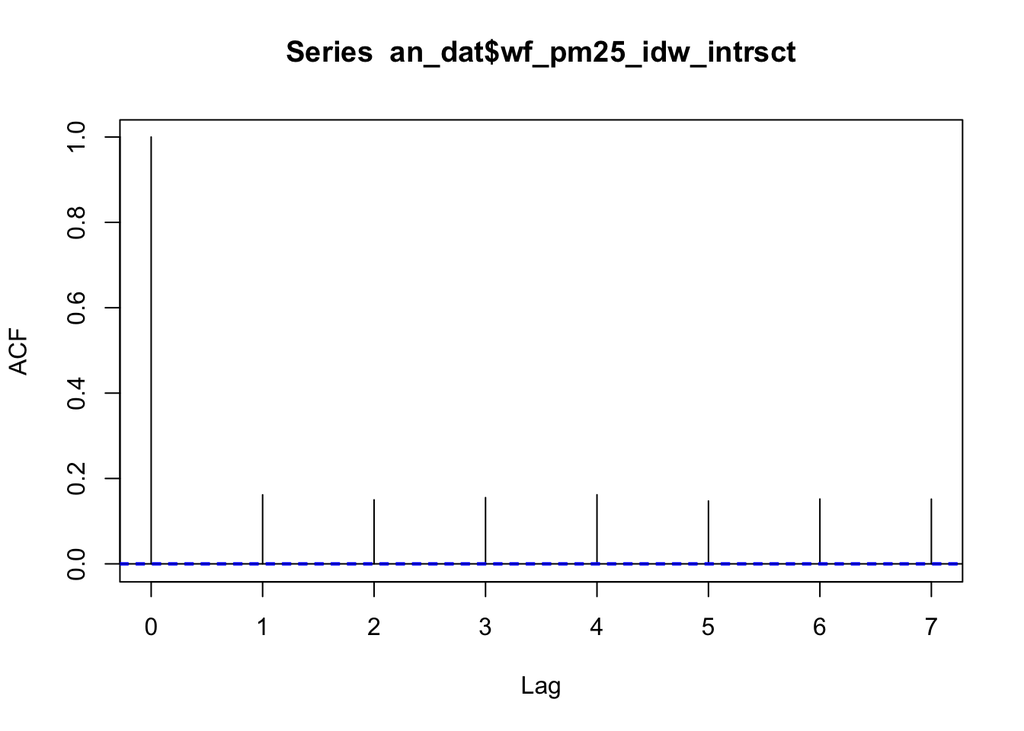

```r
acf(an_dat$wf_pm25_idw_intrsct, lag.max = 7, na.action = na.pass)
```

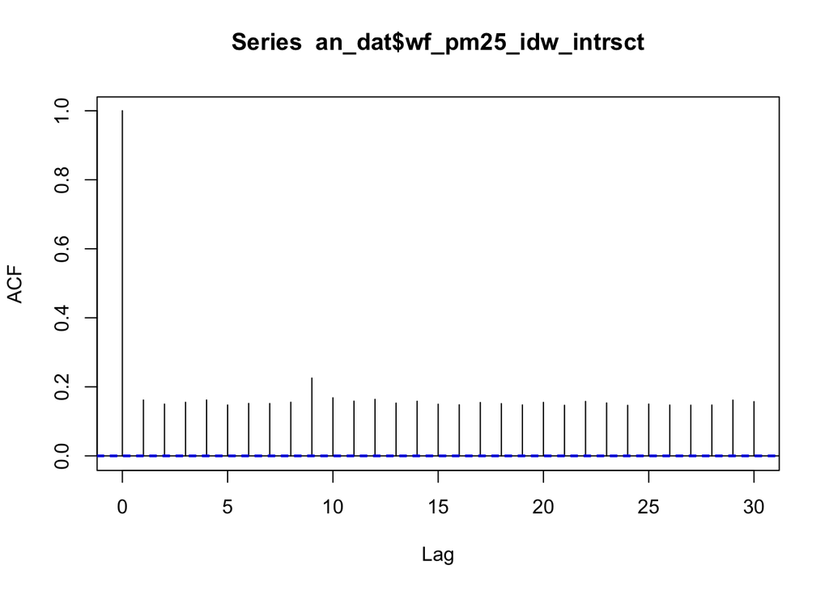

```r
acf(an_dat$wf_pm25_idw_intrsct, lag.max = 30, na.action = na.pass)
```

Lag all exposures:

```r
an_dat <- an_dat %>% mutate(
  wf_pm_Lag0 = wf_pm25_idw_intrsct,
  wf_pm_Lag1 = lag(wf_pm25_idw_intrsct, 1),
  wf_pm_Lag2 = lag(wf_pm25_idw_intrsct, 2),
  wf_pm_Lag3 = lag(wf_pm25_idw_intrsct, 3),
  wf_pm_Lag4 = lag(wf_pm25_idw_intrsct, 4),
  wf_pm_Lag5 = lag(wf_pm25_idw_intrsct, 5),
  wf_pm_Lag6 = lag(wf_pm25_idw_intrsct, 6))

an_dat <- an_dat %>% mutate(
  temp_lag0 = tmean,
  temp_lag1 = lag(tmean, 1),
  temp_lag2 = lag(tmean, 2),
  temp_lag3 = lag(tmean, 3),
  temp_lag4 = lag(tmean, 4),
  temp_lag5 = lag(tmean, 5),
  temp_lag6 = lag(tmean, 6))

an_dat <- an_dat %>% mutate(
  non_wf_pm_lag0 = mean_pm25,
  non_wf_pm_lag1 = lag(mean_pm25, 1),
  non_wf_pm_lag2 = lag(mean_pm25, 2),
  non_wf_pm_lag3 = lag(mean_pm25, 3),
  non_wf_pm_lag4 = lag(mean_pm25, 4),
  non_wf_pm_lag5 = lag(mean_pm25, 5),
  non_wf_pm_lag6 = lag(mean_pm25, 6))
```

Get mean temperature over the lag period and mean pm.

```r
an_dat$wk_mean_non_wf_pm <- rowMeans(an_dat[,39:45])
an_dat$wk_mean_temp <- rowMeans(an_dat[,32:38])
```

Create an appropriate date variable (want it to be continuous):

```r
an_dat <- an_dat %>% mutate(date = lubridate::as_date(an_dat$date))
# make a date seq bc GAM is interpreting this as a factor??
date <- sort(unique(an_dat$date))
day_seq <- seq(from = 1, to = 766, by = 0.5)
days <- data.frame(date, day_seq)
an_dat <- an_dat %>% left_join(days)
```

We’re ready to make the unconstrained lag model. Starting with outpatient visits as the outcome.

```r
m1 <- gam(data = an_dat, visitsA ~ wf_pm_Lag0 + wf_pm_Lag1 + wf_pm_Lag2 +
                  wf_pm_Lag3 + wf_pm_Lag4 + wf_pm_Lag5 + wf_pm_Lag6 +
                  s(wk_mean_non_wf_pm) + s(wk_mean_temp) +
                  ns(day_seq, df = 12),
                  family = nb(link= "log"))
```

```r
summary(m1)
```

```
##
## Family: Negative Binomial(0.499)
## Link function: log
##
## Formula:
## visitsA ~ wf_pm_Lag0 + wf_pm_Lag1 + wf_pm_Lag2 + wf_pm_Lag3 +
##     wf_pm_Lag4 + wf_pm_Lag5 + wf_pm_Lag6 + s(wk_mean_non_wf_pm) +
##     s(wk_mean_temp) + ns(day_seq, df = 12)
##
## Parametric coefficients:
##                          Estimate Std. Error z value Pr(>|z|)
## (Intercept)             0.0495165  0.0189148   2.618  0.00885 **
## wf_pm_Lag0             -0.0052372  0.0013094  -4.000 6.35e-05 ***
## wf_pm_Lag1             -0.0012766  0.0009857  -1.295  0.19529
## wf_pm_Lag2             -0.0029854  0.0010840  -2.754  0.00589 **
## wf_pm_Lag3             -0.0024434  0.0009809  -2.491  0.01274 *
## wf_pm_Lag4              0.0001965  0.0009032   0.218  0.82773
## wf_pm_Lag5             -0.0027150  0.0010441  -2.600  0.00931 **
## wf_pm_Lag6             -0.0013766  0.0009668  -1.424  0.15451
## ns(day_seq, df = 12)1   0.0268801  0.0279484   0.962  0.33616
## ns(day_seq, df = 12)2   0.1538929  0.0305540   5.037 4.74e-07 ***
## ns(day_seq, df = 12)3   0.0973525  0.0307183   3.169  0.00153 **
## ns(day_seq, df = 12)4   0.2048431  0.0290689   7.047 1.83e-12 ***
## ns(day_seq, df = 12)5   0.3918940  0.0268206  14.612  < 2e-16 ***
## ns(day_seq, df = 12)6   0.3750962  0.0317796  11.803  < 2e-16 ***
## ns(day_seq, df = 12)7   0.5704319  0.0268802  21.221  < 2e-16 ***
## ns(day_seq, df = 12)8   0.4147501  0.0285361  14.534  < 2e-16 ***
## ns(day_seq, df = 12)9  -0.0225662  0.0339834  -0.664  0.50667
## ns(day_seq, df = 12)10  0.0049677  0.0367904   0.135  0.89259
## ns(day_seq, df = 12)11 -0.3856018  0.0693059  -5.564 2.64e-08 ***
## ns(day_seq, df = 12)12 -0.6502971  0.0976197  -6.662 2.71e-11 ***
## ---
## Signif. codes:  0 '***' 0.001 '**' 0.01 '*' 0.05 '.' 0.1 ' ' 1
##
## Approximate significance of smooth terms:
##                        edf Ref.df Chi.sq p-value
## s(wk_mean_non_wf_pm) 7.156  8.195  132.3  <2e-16 ***
## s(wk_mean_temp)      8.896  8.997  437.4  <2e-16 ***
## ---
## Signif. codes:  0 '***' 0.001 '**' 0.01 '*' 0.05 '.' 0.1 ' ' 1
##
## R-sq.(adj) =  0.0147   Deviance explained = 1.42%
## -REML = 6.1348e+05  Scale est. = 1         n = 402246
```

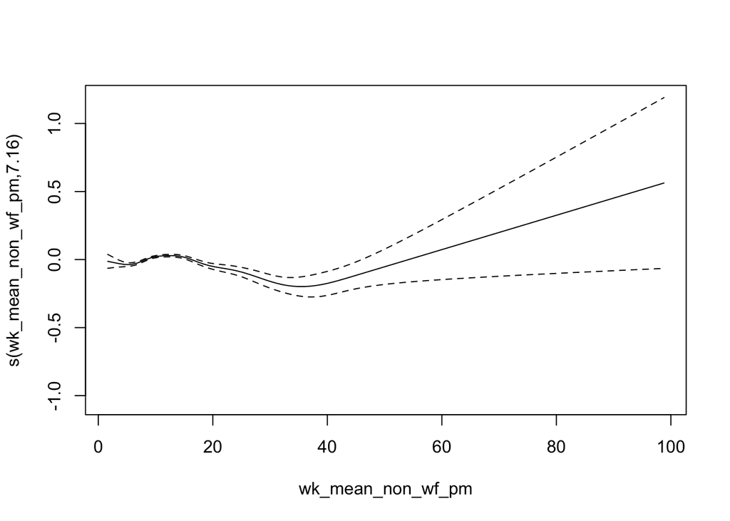

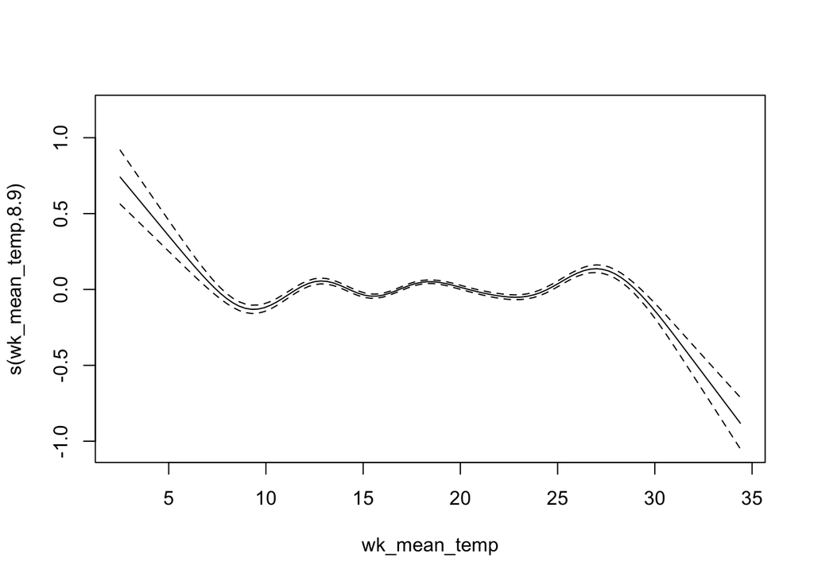

```r
plot(m1)
```

So this model doesn’t make a lot of sense to me.

First, I think we’d expect non-wf PM to have some effect on the number of hospital visits, when it looks like increased PM between 20 and 40 actually leads to fewer health care visits…

Temperature at least has a linear tail which is what we’d expect, but again it looks strange.

This model was with outpatient visits as the outcome. Going to make the rest of the models in case they are helpful.

```r
m2 <- gam(data = an_dat, visitsI ~ wf_pm_Lag0 + wf_pm_Lag1 + wf_pm_Lag2 +
                  wf_pm_Lag3 + wf_pm_Lag4 + wf_pm_Lag5 + wf_pm_Lag6 +
                  s(wk_mean_non_wf_pm) + s(wk_mean_temp) +
                  ns(day_seq, df = 12),
                  family = nb(link= "log"))
```

```r
summary(m2)
```

```
##
## Family: Negative Binomial(0.046)
## Link function: log
##
## Formula:
## visitsI ~ wf_pm_Lag0 + wf_pm_Lag1 + wf_pm_Lag2 + wf_pm_Lag3 +
##     wf_pm_Lag4 + wf_pm_Lag5 + wf_pm_Lag6 + s(wk_mean_non_wf_pm) +
##     s(wk_mean_temp) + ns(day_seq, df = 12)
##
## Parametric coefficients:
##                          Estimate Std. Error z value Pr(>|z|)
## (Intercept)            -3.9380374  0.0927348 -42.466  < 2e-16 ***
## wf_pm_Lag0             -0.0018531  0.0045856  -0.404 0.686139
## wf_pm_Lag1             -0.0126958  0.0069995  -1.814 0.069706 .
## wf_pm_Lag2             -0.0011909  0.0041625  -0.286 0.774801
## wf_pm_Lag3             -0.0004275  0.0036113  -0.118 0.905765
## wf_pm_Lag4              0.0044952  0.0028809   1.560 0.118677
## wf_pm_Lag5              0.0009453  0.0033612   0.281 0.778520
## wf_pm_Lag6             -0.0006354  0.0039000  -0.163 0.870589
## ns(day_seq, df = 12)1  -0.0916930  0.1295920  -0.708 0.479224
## ns(day_seq, df = 12)2   0.3219320  0.1453640   2.215 0.026783 *
## ns(day_seq, df = 12)3   0.0874256  0.1397714   0.625 0.531649
## ns(day_seq, df = 12)4   0.4907998  0.1320716   3.716 0.000202 ***
## ns(day_seq, df = 12)5   1.3559976  0.1173527  11.555  < 2e-16 ***
## ns(day_seq, df = 12)6   0.9814710  0.1367570   7.177 7.14e-13 ***
## ns(day_seq, df = 12)7   1.7291998  0.1152240  15.007  < 2e-16 ***
## ns(day_seq, df = 12)8   1.2612021  0.1209077  10.431  < 2e-16 ***
## ns(day_seq, df = 12)9   0.6302921  0.1435332   4.391 1.13e-05 ***
## ns(day_seq, df = 12)10  0.7338139  0.1516036   4.840 1.30e-06 ***
## ns(day_seq, df = 12)11 -0.1001690  0.3137531  -0.319 0.749529
## ns(day_seq, df = 12)12 -0.0802736  0.4032851  -0.199 0.842224
## ---
## Signif. codes:  0 '***' 0.001 '**' 0.01 '*' 0.05 '.' 0.1 ' ' 1
##
## Approximate significance of smooth terms:
##                        edf Ref.df Chi.sq p-value
## s(wk_mean_non_wf_pm) 1.016  1.032  0.143   0.723
## s(wk_mean_temp)      1.017  1.035  0.277   0.608
##
## R-sq.(adj) =  0.00607   Deviance explained = 5.65%
## -REML =  60604  Scale est. = 1         n = 402246
```

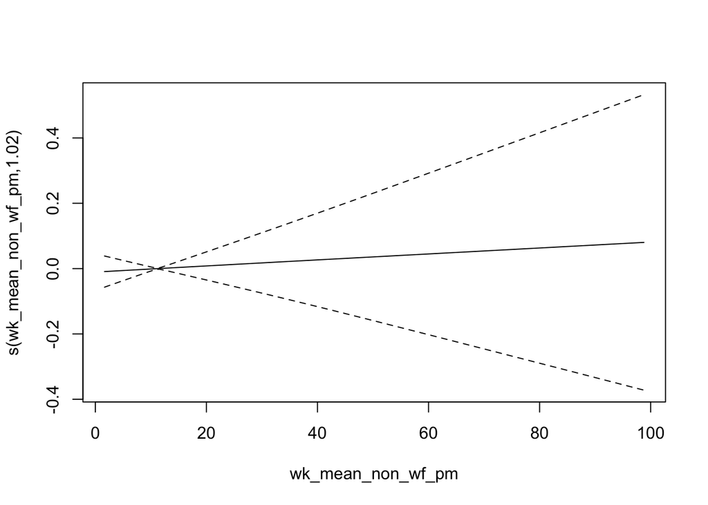

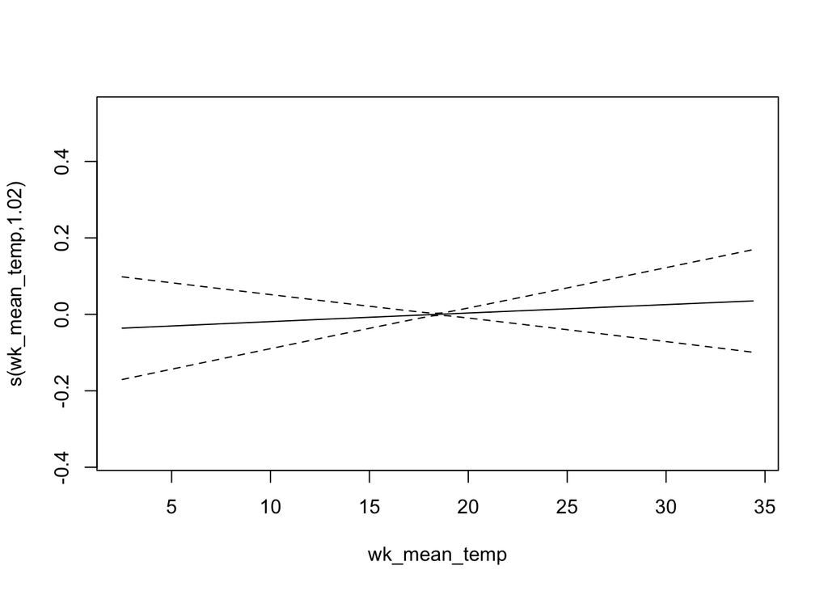

```r
plot(m2)
```

```r
m3 <- gam(data = an_dat, visitsIC ~ wf_pm_Lag0 + wf_pm_Lag1 + wf_pm_Lag2 +
                  wf_pm_Lag3 + wf_pm_Lag4 + wf_pm_Lag5 + wf_pm_Lag6 +
                  s(wk_mean_non_wf_pm) + s(wk_mean_temp) +
                  ns(day_seq, df = 12),
                  family = nb(link= "log"))
```

```r
summary(m3)
```

```
##
## Family: Negative Binomial(0.042)
## Link function: log
##
## Formula:
## visitsIC ~ wf_pm_Lag0 + wf_pm_Lag1 + wf_pm_Lag2 + wf_pm_Lag3 +
##     wf_pm_Lag4 + wf_pm_Lag5 + wf_pm_Lag6 + s(wk_mean_non_wf_pm) +
##     s(wk_mean_temp) + ns(day_seq, df = 12)
##
## Parametric coefficients:
##                          Estimate Std. Error z value Pr(>|z|)
## (Intercept)            -3.9727447  0.0961155 -41.333  < 2e-16 ***
## wf_pm_Lag0             -0.0026942  0.0051584  -0.522  0.60147
## wf_pm_Lag1             -0.0120721  0.0073100  -1.651  0.09865 .
## wf_pm_Lag2              0.0005068  0.0037345   0.136  0.89206
## wf_pm_Lag3             -0.0024642  0.0046517  -0.530  0.59630
## wf_pm_Lag4              0.0038291  0.0030634   1.250  0.21132
## wf_pm_Lag5              0.0009686  0.0034942   0.277  0.78163
## wf_pm_Lag6             -0.0012464  0.0043115  -0.289  0.77252
## ns(day_seq, df = 12)1  -0.1766310  0.1357768  -1.301  0.19330
## ns(day_seq, df = 12)2   0.2602386  0.1517024   1.715  0.08626 .
## ns(day_seq, df = 12)3   0.0439873  0.1459305   0.301  0.76309
## ns(day_seq, df = 12)4   0.4240317  0.1377614   3.078  0.00208 **
## ns(day_seq, df = 12)5   1.2965411  0.1223535  10.597  < 2e-16 ***
## ns(day_seq, df = 12)6   0.8666079  0.1430383   6.059 1.37e-09 ***
## ns(day_seq, df = 12)7   1.6580142  0.1201443  13.800  < 2e-16 ***
## ns(day_seq, df = 12)8   1.1824956  0.1261495   9.374  < 2e-16 ***
## ns(day_seq, df = 12)9   0.5801175  0.1500309   3.867  0.00011 ***
## ns(day_seq, df = 12)10  0.6631492  0.1592532   4.164 3.13e-05 ***
## ns(day_seq, df = 12)11 -0.2137829  0.3281344  -0.652  0.51472
## ns(day_seq, df = 12)12 -0.0466948  0.4244330  -0.110  0.91240
## ---
## Signif. codes:  0 '***' 0.001 '**' 0.01 '*' 0.05 '.' 0.1 ' ' 1
##
## Approximate significance of smooth terms:
##                       edf Ref.df Chi.sq p-value
## s(wk_mean_non_wf_pm) 1.02  1.039  0.630   0.436
## s(wk_mean_temp)      1.01  1.020  0.355   0.556
##
## R-sq.(adj) =  0.00532   Deviance explained = 5.43%
## -REML =  55695  Scale est. = 1         n = 402246
```

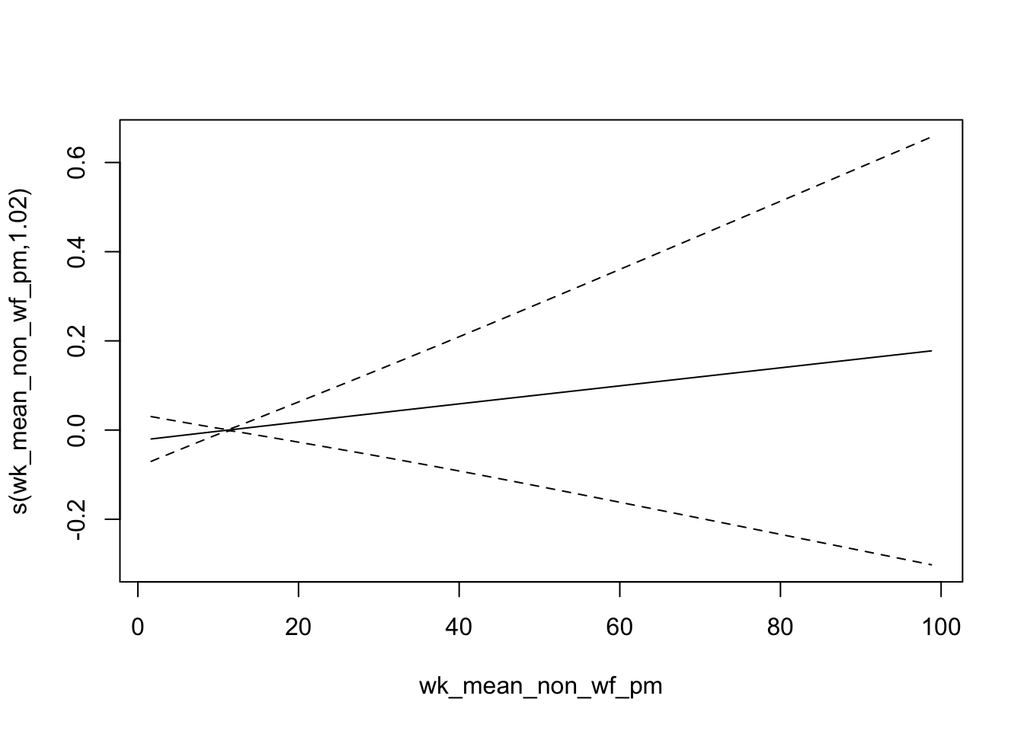

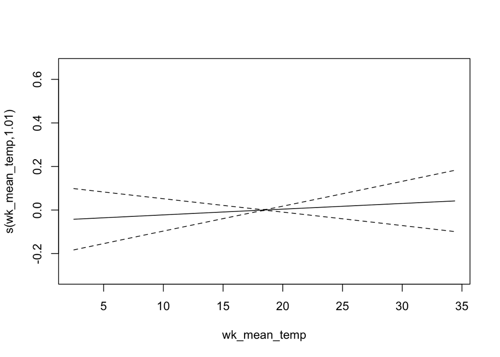

```r
plot(m3)
```

```r
m4 <- gam(data = an_dat, visitsR ~ wf_pm_Lag0 + wf_pm_Lag1 + wf_pm_Lag2 +
                  wf_pm_Lag3 + wf_pm_Lag4 + wf_pm_Lag5 + wf_pm_Lag6 +
                  s(wk_mean_non_wf_pm) + s(wk_mean_temp) +
                  ns(day_seq, df = 12),
                  family = nb(link= "log"))
```

```r
summary(m4)
```

```
##
## Family: Negative Binomial(0.092)
## Link function: log
##
## Formula:
## visitsR ~ wf_pm_Lag0 + wf_pm_Lag1 + wf_pm_Lag2 + wf_pm_Lag3 +
##     wf_pm_Lag4 + wf_pm_Lag5 + wf_pm_Lag6 + s(wk_mean_non_wf_pm) +
##     s(wk_mean_temp) + ns(day_seq, df = 12)
##
## Parametric coefficients:
##                          Estimate Std. Error z value Pr(>|z|)
## (Intercept)            -3.089e+00  6.211e-02 -49.739  < 2e-16 ***
## wf_pm_Lag0             -1.216e-02  5.014e-03  -2.425   0.0153 *
## wf_pm_Lag1             -9.298e-04  2.772e-03  -0.335   0.7373
## wf_pm_Lag2             -4.163e-03  3.699e-03  -1.125   0.2604
## wf_pm_Lag3              7.842e-04  2.218e-03   0.354   0.7237
## wf_pm_Lag4              1.017e-03  2.294e-03   0.443   0.6575
## wf_pm_Lag5              7.802e-05  2.459e-03   0.032   0.9747
## wf_pm_Lag6              2.301e-03  2.175e-03   1.058   0.2902
## ns(day_seq, df = 12)1  -1.091e-01  8.722e-02  -1.251   0.2110
## ns(day_seq, df = 12)2   4.053e-01  9.746e-02   4.158 3.20e-05 ***
## ns(day_seq, df = 12)3   1.228e-01  9.475e-02   1.296   0.1950
## ns(day_seq, df = 12)4   4.009e-01  9.059e-02   4.425 9.63e-06 ***
## ns(day_seq, df = 12)5   9.481e-01  8.141e-02  11.646  < 2e-16 ***
## ns(day_seq, df = 12)6   7.453e-01  9.513e-02   7.834 4.71e-15 ***
## ns(day_seq, df = 12)7   1.310e+00  7.998e-02  16.376  < 2e-16 ***
## ns(day_seq, df = 12)8   9.436e-01  8.425e-02  11.200  < 2e-16 ***
## ns(day_seq, df = 12)9   5.092e-01  9.966e-02   5.110 3.23e-07 ***
## ns(day_seq, df = 12)10  5.363e-01  1.063e-01   5.048 4.47e-07 ***
## ns(day_seq, df = 12)11  5.543e-02  2.138e-01   0.259   0.7955
## ns(day_seq, df = 12)12 -5.400e-02  2.819e-01  -0.192   0.8481
## ---
## Signif. codes:  0 '***' 0.001 '**' 0.01 '*' 0.05 '.' 0.1 ' ' 1
##
## Approximate significance of smooth terms:
##                        edf Ref.df Chi.sq p-value
## s(wk_mean_non_wf_pm) 1.529  1.919  7.514  0.0308 *
## s(wk_mean_temp)      1.013  1.026  2.616  0.1090
## ---
## Signif. codes:  0 '***' 0.001 '**' 0.01 '*' 0.05 '.' 0.1 ' ' 1
##
## R-sq.(adj) =  0.00627   Deviance explained = 3.15%
## -REML = 1.0358e+05  Scale est. = 1         n = 402246
```

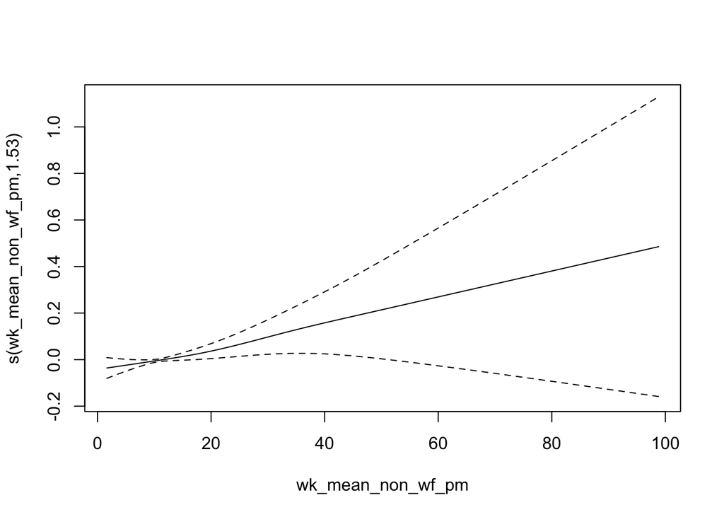

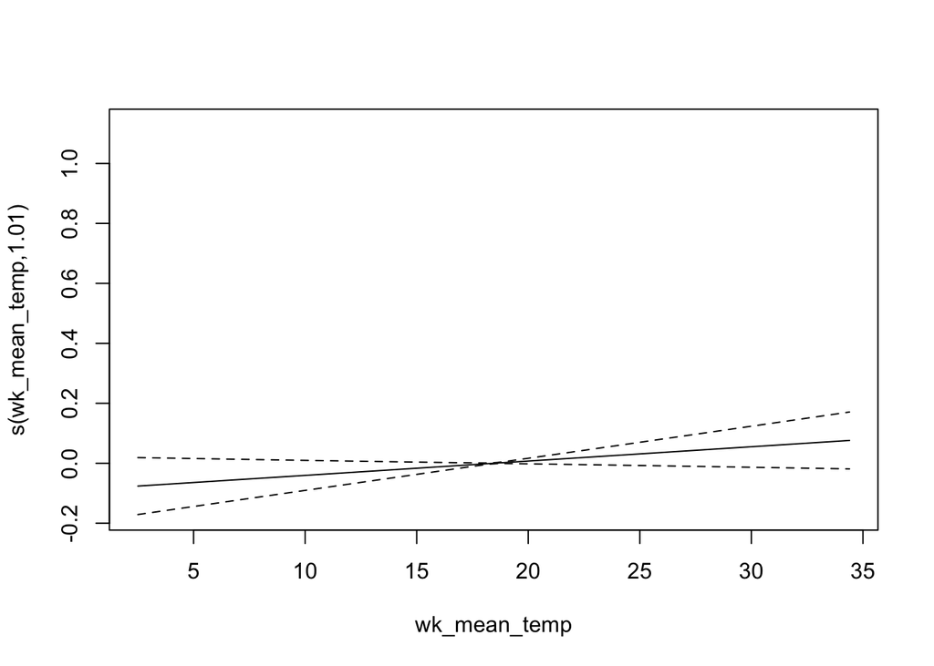

```r
plot(m4)
```

```r
m5 <- gam(data = an_dat, visitsRC ~ wf_pm_Lag0 + wf_pm_Lag1 + wf_pm_Lag2 +
                  wf_pm_Lag3 + wf_pm_Lag4 + wf_pm_Lag5 + wf_pm_Lag6 +
                  s(wk_mean_non_wf_pm) + s(wk_mean_temp) +
                  ns(day_seq, df = 12),
                  family = nb(link= "log"))
```

```r
summary(m5)
```

```
##
## Family: Negative Binomial(0.076)
## Link function: log
##
## Formula:
## visitsRC ~ wf_pm_Lag0 + wf_pm_Lag1 + wf_pm_Lag2 + wf_pm_Lag3 +
##     wf_pm_Lag4 + wf_pm_Lag5 + wf_pm_Lag6 + s(wk_mean_non_wf_pm) +
##     s(wk_mean_temp) + ns(day_seq, df = 12)
##
## Parametric coefficients:
##                          Estimate Std. Error z value Pr(>|z|)
## (Intercept)            -3.3195881  0.0692913 -47.908  < 2e-16 ***
## wf_pm_Lag0             -0.0124804  0.0055692  -2.241 0.025028 *
## wf_pm_Lag1              0.0005250  0.0027507   0.191 0.848644
## wf_pm_Lag2             -0.0038744  0.0040442  -0.958 0.338057
## wf_pm_Lag3              0.0012128  0.0023977   0.506 0.612996
## wf_pm_Lag4              0.0017227  0.0024492   0.703 0.481836
## wf_pm_Lag5              0.0004926  0.0026566   0.185 0.852907
## wf_pm_Lag6              0.0025107  0.0023856   1.052 0.292609
## ns(day_seq, df = 12)1  -0.1566133  0.0971510  -1.612 0.106949
## ns(day_seq, df = 12)2   0.4726415  0.1083605   4.362 1.29e-05 ***
## ns(day_seq, df = 12)3   0.1151206  0.1054049   1.092 0.274756
## ns(day_seq, df = 12)4   0.3792343  0.1007948   3.762 0.000168 ***
## ns(day_seq, df = 12)5   1.0326238  0.0904218  11.420  < 2e-16 ***
## ns(day_seq, df = 12)6   0.6953519  0.1058473   6.569 5.05e-11 ***
## ns(day_seq, df = 12)7   1.3855368  0.0890819  15.554  < 2e-16 ***
## ns(day_seq, df = 12)8   0.8377169  0.0945999   8.855  < 2e-16 ***
## ns(day_seq, df = 12)9   0.3210006  0.1125247   2.853 0.004335 **
## ns(day_seq, df = 12)10  0.5748546  0.1209687   4.752 2.01e-06 ***
## ns(day_seq, df = 12)11 -0.2253278  0.2437700  -0.924 0.355306
## ns(day_seq, df = 12)12 -0.5647974  0.3259901  -1.733 0.083174 .
## ---
## Signif. codes:  0 '***' 0.001 '**' 0.01 '*' 0.05 '.' 0.1 ' ' 1
##
## Approximate significance of smooth terms:
##                        edf Ref.df Chi.sq p-value
## s(wk_mean_non_wf_pm) 1.369  1.667  4.743  0.0978 .
## s(wk_mean_temp)      1.009  1.018  4.451  0.0360 *
## ---
## Signif. codes:  0 '***' 0.001 '**' 0.01 '*' 0.05 '.' 0.1 ' ' 1
##
## R-sq.(adj) =  0.00521   Deviance explained =  3.1%
## -REML =  86064  Scale est. = 1         n = 402246
```

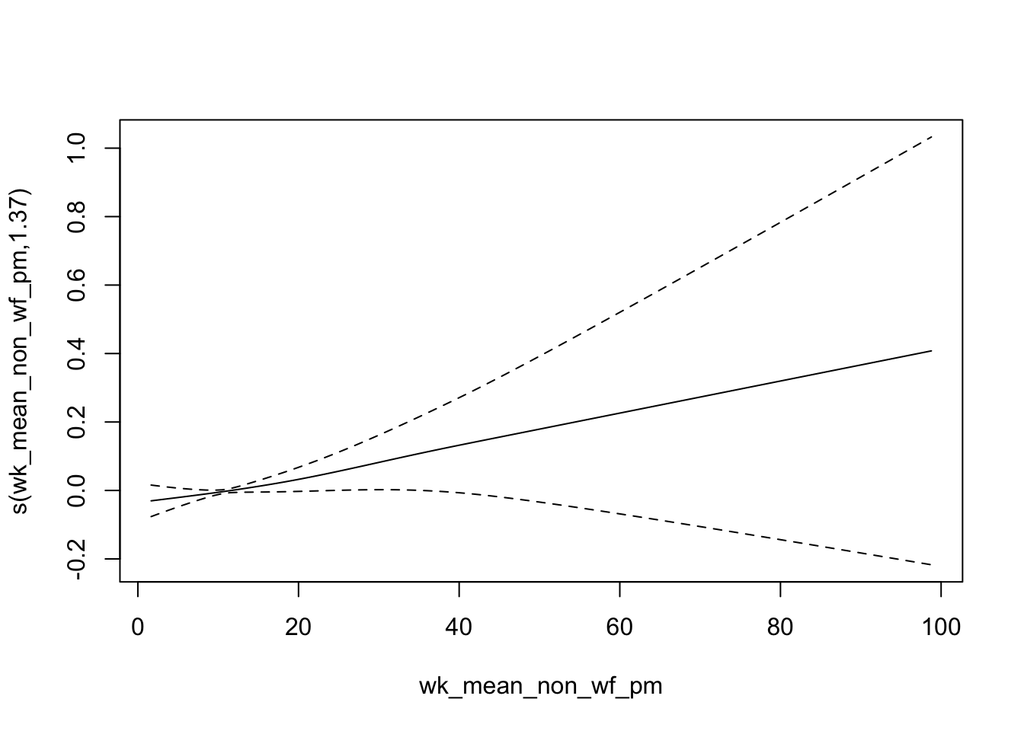

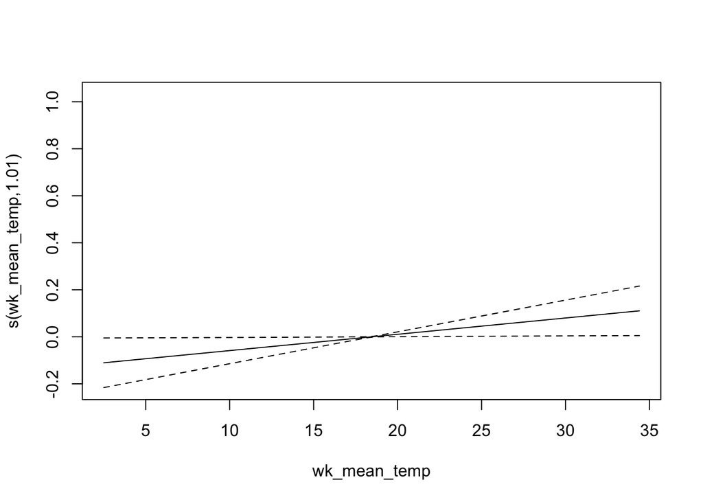

```r
plot(m5)
```